# Phillies Question 2

Will Moscato

2022-08-18

```r
library(tidyverse)
library(dplyr)
library(readr)
library(broom)
library(ggplot2)
library(tidymodels)
library(vip)
library(stacks)
library(DALEX)
library(DALEXtra)
library(themis)
library(pitchRx)
library(kableExtra)
library(webshot)
library(magick)
library(viridis)
set.seed(666)
tidymodels_prefer()


theme_set(theme_minimal())
```

# Introduction

In this project I was asked to predicted the end of the season OBP based upon the players March and April hitting stats. I created this prediction by making a KNN machine learning model (reasons for chosing this model will be explained later), and the prediction was fairly accurate.

# Data

```r
batting <- read_csv("batting.csv")
batting <- batting %>%
  mutate(across(ends_with("%"), ~gsub("\\%", "", .)))


batting$`MarApr_HR/FB` = gsub("\\%", "", batting$`MarApr_HR/FB`)

batting <- batting %>%
  mutate(across(ends_with("%"), ~as.numeric(.))) %>%
  mutate(`MarApr_HR/FB` = as.numeric(`MarApr_HR/FB`))

battingsplit <- initial_split(batting, strata = "FullSeason_OBP")
batting_train <- training(battingsplit)
batting_testing <- testing(battingsplit)


batting_train <- batting %>%
  select(-playerid, -Name, -Team)
```

# Exploratory

Before I started doing any modeling I wanted to see how well the player’s OBP in March and April predicted the end of season OBP. As it turns out, it does a fairly good job, giving us an RMSE of ~0.047. This is expected, as we wouldn’t expect a player’s OBP to drastically change over the course of the season. However, I was sure we could do better.

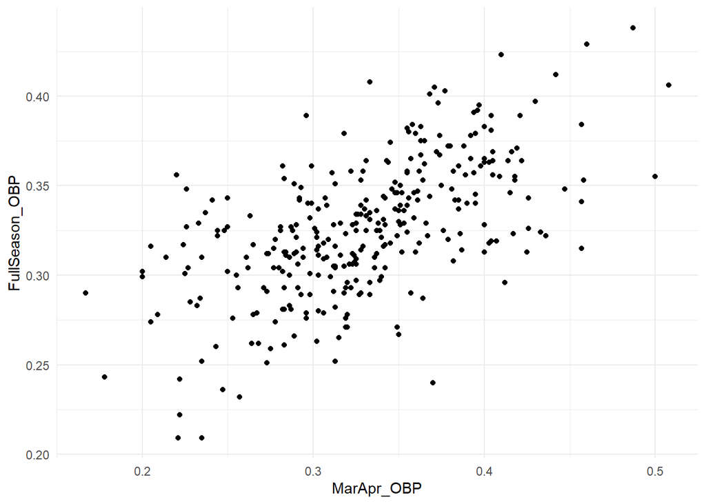

```r
batting %>%
  ggplot(aes(x = MarApr_OBP, y = FullSeason_OBP)) +
  geom_point()
```

```r
OBP_to_OBP <- rmse(batting, truth = FullSeason_OBP, estimate = MarApr_OBP)

kable(OBP_to_OBP, align = c(rep('c', 1)), col.names = c("Metric", "Estimator", "Estimate")) %>%
  row_spec(0) %>%
  kable_styling(full_width = T, bootstrap_options = "striped", font_size = 20) %>%
  add_header_above(c("RMSE of using March/April OBP as Predictor" = 3), background = "red", color = "white")
```

| RMSE of using March/April OBP as Predictor Metric | RMSE of using March/April OBP as Predictor Estimator | RMSE of using March/April OBP as Predictor Estimate |
| --- | --- | --- |
| rmse | standard | 0.0473925 |

# Modeling

In the modeling process I tried three different types of models: lasso, random forest, and knn. While they all gave very similar RMSE’s, I decided to go with the knn for a few reasons. First, because KNN models are very accurate and are good when you have knowledge of the domain of what you are trying to predict. Second, the data set was not too large (and would never be that large) and thus the prediction will not be slow. And lastly, in this specific case, the variable importance of the knn made more sense making it seem like the prediction would do better on other data sets than the lasso (which had the best rmse).

First I had to create the cross validation folds. Then, I specified that I would be using a knn model for regression and set the number of neighbors to tune so that I could try different values. Then, I created the recipe for the model in which I decided to remove stolen bases and runs as they do not have anything to do with hitting and thus have nothing to do with OBP. Next, I created the tune grid for how many neighbors the model should use and I set the range between 1 and 25 as I didn’t want to overfit or have the prediction take too long. Lastly, I fit the tune grid to the workflow.

```r
data_cv10 <- vfold_cv(batting_train, v = 10) # cross-validation folds


# Model Specification
knn_spec <-
  nearest_neighbor() %>%
  set_args(neighbors = tune()) %>%
  set_engine(engine = 'kknn') %>%
  set_mode('regression')

# Recipe
knn_batting_rec <- recipe(FullSeason_OBP ~ . , data = batting_train) %>%
    step_nzv(all_predictors()) %>% # removes variables with the same value
    step_rm(MarApr_SB, MarApr_R) %>% # remove stolen bases and runs as they don't have anything to do with obp
    step_novel(all_nominal_predictors()) %>% # important if you have rare categorical variables
    step_normalize(all_numeric_predictors()) %>%  # standardization step
    step_dummy(all_nominal_predictors())  # indicator variables for categorical variables

# Workflow
knn_wf <- workflow() %>%
  add_model(knn_spec) %>%
  add_recipe(knn_batting_rec)

# Tuning
knn_tune_grid <- grid_regular(
  neighbors(range = c(1, 25)),
  levels = 25)

knn_fit_cv <- tune_grid(knn_wf,
              resamples = data_cv10,
              grid = knn_tune_grid,
              metrics = metric_set(rmse, mae))
```

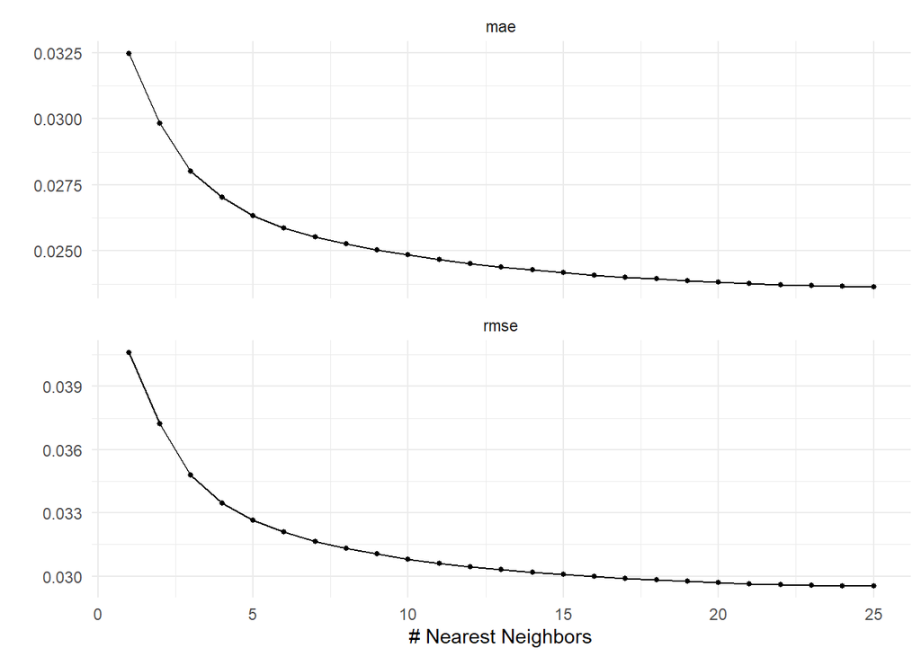

```r
knn_fit_cv %>% autoplot() # Visualize Trained Model using CV
```

```r
cv_fit <- knn_fit_cv %>% show_best(metric = 'rmse')


kable(cv_fit, align = c(rep('c', 1)), col.names = c("Number of Neighbors", "Metric", "Estimator", "Estimate", "n", "Standard Error", "Model")) %>%
  row_spec(0) %>%
  kable_styling(full_width = T, bootstrap_options = "striped", font_size = 20) %>%
  add_header_above(c("RMSE of using March/April OBP as Predictor" = 7), background = "red", color = "white")
```

[output not shown]

```r
# Choose value of Tuning Paramete
tuned_knn_wf <- knn_fit_cv %>%
  select_by_one_std_err(metric = 'rmse',desc(neighbors)) %>%
  finalize_workflow(knn_wf, .)

# Fit final KNN model to data
knn_fit_final <- tuned_knn_wf %>%
  fit(data = batting_train)
```

Then I fit the model to the testing data to see how it preforms and to ensure that the model is reproducible.

```r
knn_fit <- last_fit(knn_fit_final, battingsplit)
knn_fit_collection <- collect_metrics(knn_fit)

kable(knn_fit_collection, align = c(rep('c', 1)), col.names = c("Metric", "Estimator", "Estimate", "Model")) %>%
  row_spec(0) %>%
  kable_styling(full_width = T, bootstrap_options = "striped", font_size = 20) %>%
  add_header_above(c("RMSE of using March/April OBP as Predictor" = 4), background = "red", color = "white")
```

[output not shown]

Then we create the prediction on the testing data and bind it to the data set so that we can see the prediction and the actual value side by side.

```r
pred <- predict(knn_fit_final, new_data = batting_testing)

batting_knn_testing <- cbind(batting_testing, pred)
batting_knn_testing <- batting_knn_testing %>%
  select(Name, Team, FullSeason_OBP, .pred)

test_head <- head(batting_knn_testing)


kable(test_head, align = c(rep('c', 1)), col.names = c("Name", "Team", "Full Season OBP", "Predicted OBP")) %>%
  row_spec(0) %>%
  kable_styling(full_width = T, bootstrap_options = "striped", font_size = 20) %>%
  add_header_above(c("RMSE of using March/April OBP as Predictor" = 4), background = "red", color = "white")
```

[output not shown]

```r
knn_batting_explain <-
  explain_tidymodels(
    model = knn_fit_final,
    data = batting_train %>% select(-FullSeason_OBP),
    y = as.numeric(batting_train$FullSeason_OBP),
    label = "knn"
  )
```

```
## Preparation of a new explainer is initiated
##   -> model label       :  knn
##   -> data              :  320  rows  25  cols
##   -> data              :  tibble converted into a data.frame
##   -> target variable   :  320  values
##   -> predict function  :  yhat.workflow  will be used (  default  )
##   -> predicted values  :  No value for predict function target column. (  default  )
##   -> model_info        :  package tidymodels , ver. 0.2.0 , task regression (  default  )
##   -> predicted values  :  numerical, min =  0.269681 , mean =  0.3243576 , max =  0.3773294
##   -> residual function :  difference between y and yhat (  default  )
##   -> residuals         :  numerical, min =  -0.07208869 , mean =  0.001267383 , max =  0.08581379
##   A new explainer has been created!
```

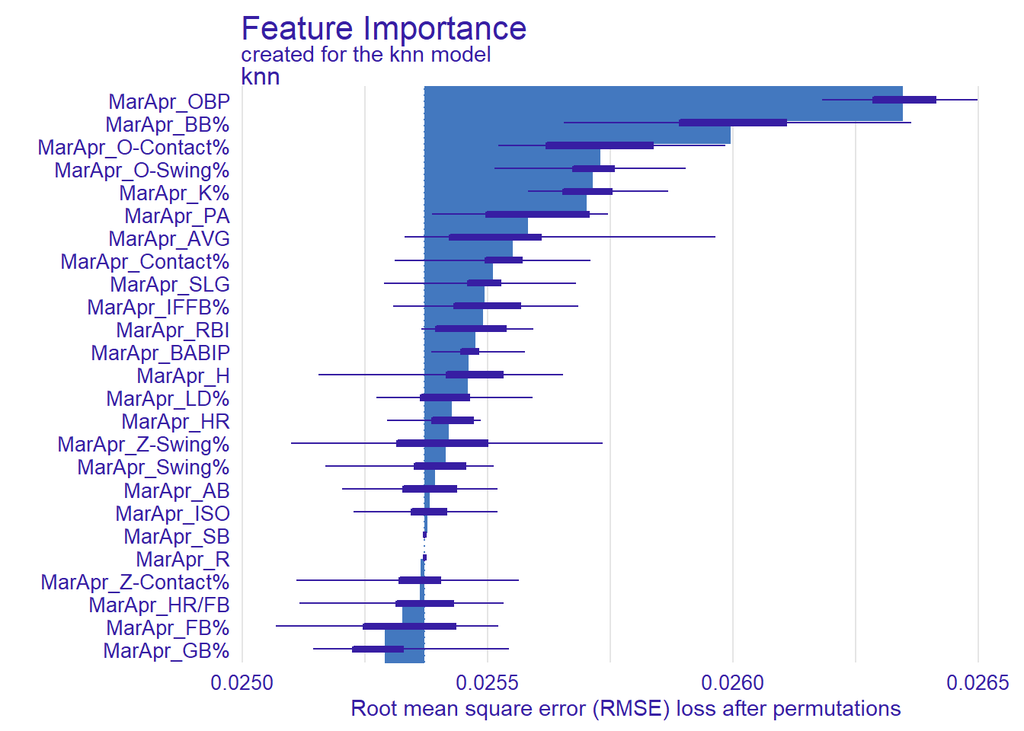

```r
knn_batting_var_imp <-
  model_parts(
    knn_batting_explain
    )

plot(knn_batting_var_imp)
```

Lastly, I created a visual to see how each variable was affecting the prediction for a specific player. I think that this give us a better idea of how the model is working as a whole.

[figure not shown]

```r
new_obs_1 <- batting_testing %>% filter(Name == "Rougned Odor")

#Pulls together the data needed for the break-down plot
Odor <- predict_parts(explainer = knn_batting_explain,
                          new_observation = new_obs_1,
                          type = "break_down") #default
Odor_pp <- plot(Odor, title = "Rougned Odor Prediction") + theme(plot.title = element_text(hjust = .5, size = 15, color = "black", face = "bold"))

Odor_pp
```

# Conclusion

In conclusion, I was able to create a model that got the prediction within ~30 points of the actual end of season OBP. I used a knn model due to the accuracy as well as the variables it was using that lead me to believe its predictions are more reproducible. While just using the OBP from March and April is fairly good, my prediction gets us ~17 points closer to the actual OBP.